# Home Credit Default Risk

## LightGBM

```r
# Prepare data for LightGBM
lgb_train <- lgb.Dataset(data = as.matrix(train_x), label = as.numeric(train_y) - 1)
lgb_test <- lgb.Dataset(data = as.matrix(test_x), label = as.numeric(test_y) - 1)

# Set parameters for LightGBM
lgb_params <- list(
  objective = "binary",
  metric = "auc",
  scale_pos_weight = sum(train_y == 0) / sum(train_y == 1),  # Class weights
  learning_rate = 0.1,
  num_leaves = 31,
  feature_fraction = 0.8,
  bagging_fraction = 0.8,
  bagging_freq = 5
)

# Train LightGBM model
set.seed(123)
lgb_model <- lgb.train(
  params = lgb_params,
  data = lgb_train,
  nrounds = 100,
  valids = list(test = lgb_test),
  early_stopping_rounds = 10
)
```

```
## [LightGBM] [Info] Number of positive: 19860, number of negative: 226149
## [LightGBM] [Info] Auto-choosing row-wise multi-threading, the overhead of testing was 0.017791 seconds.
## You can set `force_row_wise=true` to remove the overhead.
## And if memory is not enough, you can set `force_col_wise=true`.
## [LightGBM] [Info] Total Bins 2320
## [LightGBM] [Info] Number of data points in the train set: 246009, number of used features: 46
## [LightGBM] [Info] [binary:BoostFromScore]: pavg=0.080729 -> initscore=-2.432486
## [LightGBM] [Info] Start training from score -2.432486
## [1]:  test's auc:0.70654
## Will train until there is no improvement in 10 rounds.
## [2]:  test's auc:0.714698
## [3]:  test's auc:0.717346
## [4]:  test's auc:0.71995
## [5]:  test's auc:0.721126
## [6]:  test's auc:0.722471
## [7]:  test's auc:0.723116
## [8]:  test's auc:0.723813
## [9]:  test's auc:0.72413
## [10]:  test's auc:0.724723
## [11]:  test's auc:0.725176
## [12]:  test's auc:0.725738
## [13]:  test's auc:0.72654
## [14]:  test's auc:0.726851
## [15]:  test's auc:0.727393
## [16]:  test's auc:0.727531
## [17]:  test's auc:0.727886
## [18]:  test's auc:0.728121
## [19]:  test's auc:0.72826
## [20]:  test's auc:0.728592
## [21]:  test's auc:0.729264
## [22]:  test's auc:0.729585
## [23]:  test's auc:0.729733
## [24]:  test's auc:0.729809
## [25]:  test's auc:0.730005
## [26]:  test's auc:0.730112
## [27]:  test's auc:0.73022
## [28]:  test's auc:0.730313
## [29]:  test's auc:0.730651
## [30]:  test's auc:0.730708
## [31]:  test's auc:0.731007
```

[output cut: 33 more lines]

```
## [65]:  test's auc:0.733802
## [66]:  test's auc:0.733826
## [67]:  test's auc:0.733952
## [68]:  test's auc:0.733967
## [69]:  test's auc:0.733904
## [70]:  test's auc:0.733813
## [71]:  test's auc:0.73387
## [72]:  test's auc:0.733951
## [73]:  test's auc:0.733935
## [74]:  test's auc:0.733914
## [75]:  test's auc:0.733901
## [76]:  test's auc:0.73382
## [77]:  test's auc:0.733753
## [78]:  test's auc:0.733941
## Early stopping, best iteration is: [68]:  test's auc:0.733967
```

```r
# Predictions
lgb_predictions <- predict(lgb_model, as.matrix(test_x))
lgb_class <- ifelse(lgb_predictions > 0.5, 1, 0)

# Evaluate performance
lgb_confusion <- confusionMatrix(factor(lgb_class), test_y, positive = "1")

# Extract metrics
accuracy <- lgb_confusion$overall["Accuracy"]
kappa <- lgb_confusion$overall["Kappa"]
sensitivity <- lgb_confusion$byClass["Sensitivity"]
specificity <- lgb_confusion$byClass["Specificity"]
pos_pred_value <- lgb_confusion$byClass["Pos Pred Value"]
neg_pred_value <- lgb_confusion$byClass["Neg Pred Value"]
prevalence <- lgb_confusion$byClass["Prevalence"]
detection_rate <- lgb_confusion$byClass["Detection Rate"]
detection_prevalence <- lgb_confusion$byClass["Detection Prevalence"]
balanced_accuracy <- lgb_confusion$byClass["Balanced Accuracy"]

# Print the confusion matrix and statistics
print(lgb_confusion)
```

```
## Confusion Matrix and Statistics
##
##           Reference
## Prediction     0     1
##          0 38517  1653
##          1 18020  3312
##
##                Accuracy : 0.6801
##                  95% CI : (0.6764, 0.6838)
##     No Information Rate : 0.9193
##     P-Value [Acc > NIR] : 1
##
##                   Kappa : 0.1391
##
##  Mcnemar's Test P-Value : <2e-16
##
##             Sensitivity : 0.66707
##             Specificity : 0.68127
##          Pos Pred Value : 0.15526
##          Neg Pred Value : 0.95885
##              Prevalence : 0.08073
##          Detection Rate : 0.05385
##    Detection Prevalence : 0.34685
##       Balanced Accuracy : 0.67417
##
##        'Positive' Class : 1
##
```

```r
# Calculate AUC
lgb_roc_obj <- roc(as.factor(test_y), lgb_predictions, levels = c("0", "1"), positive = "1")
lgb_auc <- auc(lgb_roc_obj)

# Print AUC
print(paste("AUC for LightGBM:", lgb_auc))
```

```
## [1] "AUC for LightGBM: 0.733967480341234"
```

```r
# Calculate F1-Score
precision <- lgb_confusion$byClass["Pos Pred Value"]  # Positive Predictive Value
recall <- lgb_confusion$byClass["Sensitivity"]       # Sensitivity (Recall)
f1_score <- 2 * ((precision * recall) / (precision + recall))

# Print F1-Score
print(paste("F1-Score for LightGBM:", f1_score))
```

```
## [1] "F1-Score for LightGBM: 0.251891850781458"
```

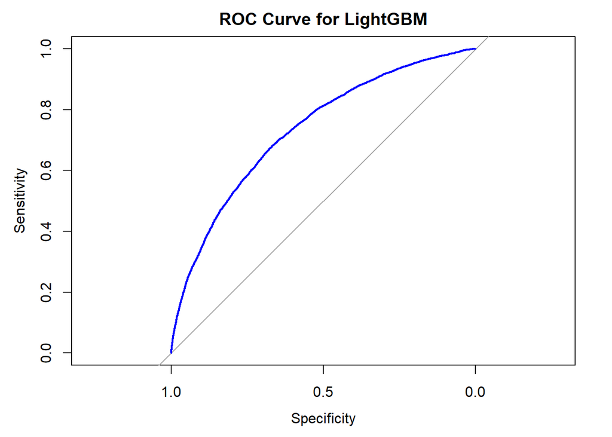

```r
# Plot ROC Curve
plot(lgb_roc_obj, main = "ROC Curve for LightGBM", col = "blue")
```

### Comparison table

```r
# Create a data frame to store the metrics for each model
comparison_table_2 <- data.frame(
  Model = c("Random Forest", "XGBoost", "LightGBM"),
  Accuracy = c(rf_confusion$overall["Accuracy"],
               xgb_confusion$overall["Accuracy"],
               lgb_confusion$overall["Accuracy"]),
  Sensitivity = c(rf_confusion$byClass["Sensitivity"],
                  xgb_confusion$byClass["Sensitivity"],
                  lgb_confusion$byClass["Sensitivity"]),
  Specificity = c(rf_confusion$byClass["Specificity"],
                  xgb_confusion$byClass["Specificity"],
                  lgb_confusion$byClass["Specificity"]),
  Precision = c(rf_confusion$byClass["Pos Pred Value"],
                xgb_confusion$byClass["Pos Pred Value"],
                lgb_confusion$byClass["Pos Pred Value"]),
  F1_Score = c(rf_f1_score, xgb_f1_score, f1_score),
  AUC = c(auc_value, xgb_auc_value, lgb_auc)
)

# Display the table using kable
kable(comparison_table_2, caption = "Comparison of Random Forest, XGBoost, and LightGBM Models")
```

Comparison of Random Forest, XGBoost, and LightGBM Models

| Model | Accuracy | Sensitivity | Specificity | Precision | F1_Score | AUC |
| --- | --- | --- | --- | --- | --- | --- |
| Random Forest | 0.9192059 | 0.0018127 | 0.9997701 | 0.4090909 | 0.0036094 | 0.6724255 |
| XGBoost | 0.7127410 | 0.5989930 | 0.7227302 | 0.1594638 | 0.2518738 | 0.7218230 |
| LightGBM | 0.6801242 | 0.6670695 | 0.6812707 | 0.1552597 | 0.2518919 | 0.7339675 |

- **Random Forest:**

High accuracy (0.91) but extremely low sensitivity (0.0018), indicating it performs poorly in detecting the minority class.

- **XGBoost:**

Balanced sensitivity (0.598) and decent AUC (0.72). However, the F1-Score (0.25) suggests it struggles with balancing precision and recall.

- **LightGBM:**

**Best AUC (0.73) among tree-based models, showing strong discrimination power. It also has balanced sensitivity (0.66) and F1-Score (0.25), making it a strong candidate for scenarios needing better minority class detection.**

## Logistic regression

### Option 1: Upsampling the minority class (SMOTE)

```r
# Create a recipe
data_recipe <- recipe(target ~ ., data = train_data) %>%
  step_smote(target)  # Apply SMOTE

# Prep the recipe
smote_recipe <- prep(data_recipe, training = train_data)

# Bake the recipe to get the balanced data
balanced_train_data_smote <- bake(smote_recipe, new_data = NULL)

# Check class balance
table(balanced_train_data_smote$target)
```

```
##
##      0      1
## 226149 226149
```

```r
# Train logistic regression on SMOTE balanced data
smote_model <- glm(target ~ ., data = balanced_train_data_smote, family = "binomial")

# Make predictions on the test set
smote_probabilities <- predict(smote_model, newdata = test_x, type = "response")
smote_predictions <- ifelse(smote_probabilities > 0.5, 1, 0)

# Confusion matrix
smote_confusion <- confusionMatrix(factor(smote_predictions), factor(test_y), positive = "1")

# Calculate AUC
smote_roc <- roc(test_y, smote_probabilities)
smote_auc <- auc(smote_roc)

# Calculate F1 Score
smote_precision <- smote_confusion$byClass["Pos Pred Value"]
smote_recall <- smote_confusion$byClass["Sensitivity"]
smote_f1_score <- 2 * ((smote_precision * smote_recall) / (smote_precision + smote_recall))

# Print metrics
print(smote_confusion)
```

```
## Confusion Matrix and Statistics
##
##           Reference
## Prediction     0     1
##          0 38467  1700
##          1 18070  3265
##
##                Accuracy : 0.6785
##                  95% CI : (0.6748, 0.6822)
##     No Information Rate : 0.9193
##     P-Value [Acc > NIR] : 1
##
##                   Kappa : 0.135
##
##  Mcnemar's Test P-Value : <2e-16
##
##             Sensitivity : 0.65760
##             Specificity : 0.68039
##          Pos Pred Value : 0.15303
##          Neg Pred Value : 0.95768
##              Prevalence : 0.08073
##          Detection Rate : 0.05309
##    Detection Prevalence : 0.34690
##       Balanced Accuracy : 0.66899
##
##        'Positive' Class : 1
##
```

```r
print(paste("AUC for SMOTE:", smote_auc))
```

```
## [1] "AUC for SMOTE: 0.72724057881086"
```

```r
print(paste("F1 Score for SMOTE:", smote_f1_score))
```

```
## [1] "F1 Score for SMOTE: 0.24828897338403"
```

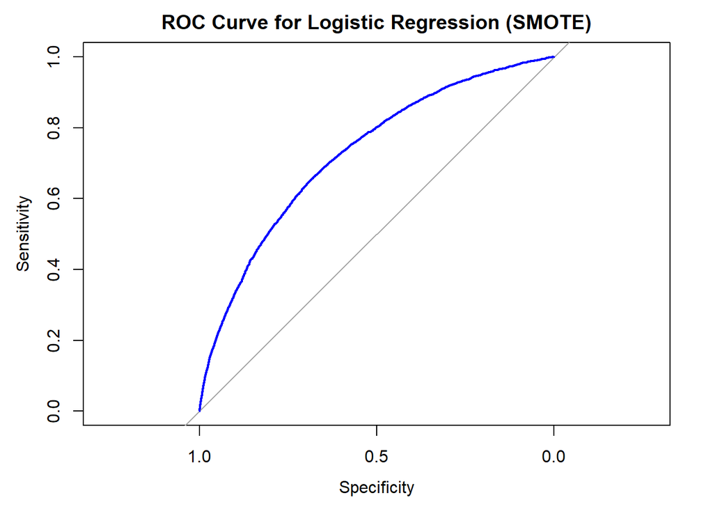

```r
# Plot ROC Curve
plot(smote_roc, main = "ROC Curve for Logistic Regression (SMOTE)", col = "blue")
```

### Option 2: Use ROSE for hybrid sampling

```r
# Apply ROSE for both downsampling and upsampling
balanced_train_data_rose <- ROSE(target ~ ., data = train_data, seed = 123)$data

# Check class balance
table(balanced_train_data_rose$target)
```

```
##
##      0      1
## 123059 122950
```

```r
# Train logistic regression on ROSE balanced data
rose_model <- glm(target ~ ., data = balanced_train_data_rose, family = "binomial")

# Make predictions on the test set
rose_probabilities <- predict(rose_model, newdata = test_x, type = "response")
rose_predictions <- ifelse(rose_probabilities > 0.5, 1, 0)

# Confusion matrix
rose_confusion <- confusionMatrix(factor(rose_predictions), factor(test_y), positive = "1")
# Calculate AUC
rose_roc <- roc(test_y, rose_probabilities)
rose_auc <- auc(rose_roc)

# Calculate F1 Score
rose_precision <- rose_confusion$byClass["Pos Pred Value"]
rose_recall <- rose_confusion$byClass["Sensitivity"]
rose_f1_score <- 2 * ((rose_precision * rose_recall) / (rose_precision + rose_recall))

# Print metrics
print(rose_confusion)
```

```
## Confusion Matrix and Statistics
##
##           Reference
## Prediction     0     1
##          0 37957  1667
##          1 18580  3298
##
##                Accuracy : 0.6708
##                  95% CI : (0.6671, 0.6745)
##     No Information Rate : 0.9193
##     P-Value [Acc > NIR] : 1
##
##                   Kappa : 0.1314
##
##  Mcnemar's Test P-Value : <2e-16
##
##             Sensitivity : 0.66425
##             Specificity : 0.67137
##          Pos Pred Value : 0.15075
##          Neg Pred Value : 0.95793
##              Prevalence : 0.08073
##          Detection Rate : 0.05362
##    Detection Prevalence : 0.35573
##       Balanced Accuracy : 0.66781
##
##        'Positive' Class : 1
##
```

```r
print(paste("AUC for ROSE:", rose_auc))
```

```
## [1] "AUC for ROSE: 0.726908879695053"
```

```r
print(paste("F1 Score for ROSE:", rose_f1_score))
```

```
## [1] "F1 Score for ROSE: 0.24572514249525"
```

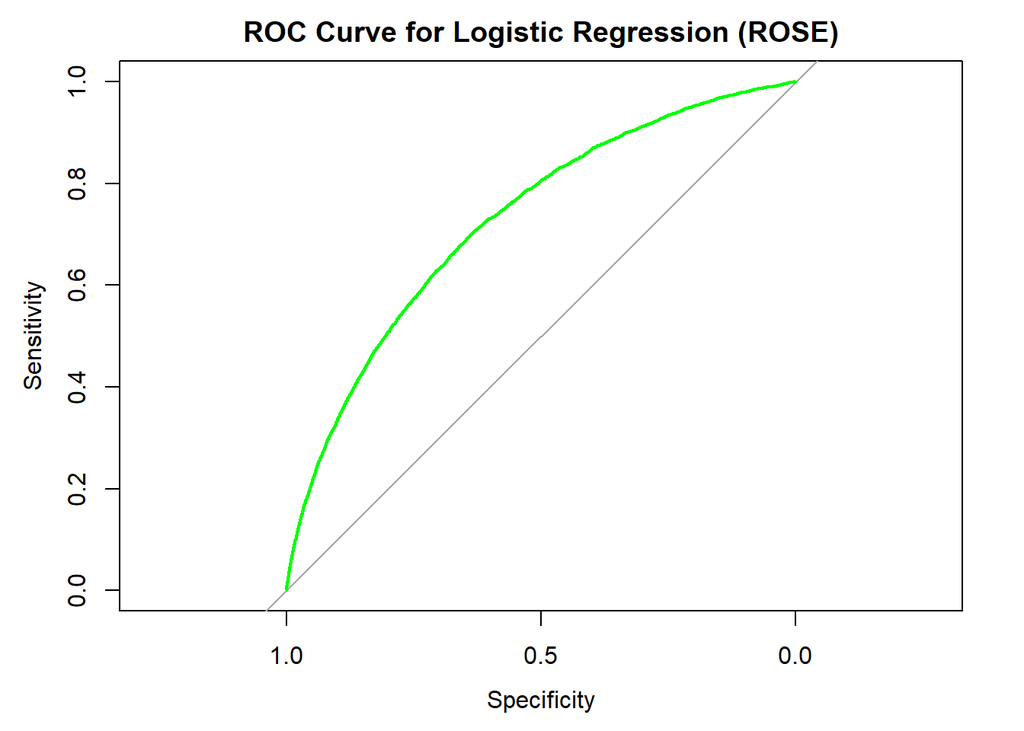

```r
# Plot ROC Curve
plot(rose_roc, main = "ROC Curve for Logistic Regression (ROSE)", col = "green")
```

### Comparison table

```r
# Create a data frame to store the metrics for each model
comparison_table_3 <- data.frame(
  Model = c("Logistic Regression (SMOTE)", "Logistic Regression (ROSE)"),
  F1_Score = c(smote_f1_score, rose_f1_score),
  AUC = c(smote_auc, rose_auc),
  Sensitivity = c(smote_confusion$byClass["Sensitivity"], rose_confusion$byClass["Sensitivity"]),
  Precision = c(smote_confusion$byClass["Pos Pred Value"], rose_confusion$byClass["Pos Pred Value"]),
  Accuracy = c(smote_confusion$overall["Accuracy"], rose_confusion$overall["Accuracy"])
)

# Display the table using kable
kable(comparison_table_3, caption = "Comparison of Logistic Regression Models with SMOTE and ROSE")
```

Comparison of Logistic Regression Models with SMOTE and ROSE

| Model | F1_Score | AUC | Sensitivity | Precision | Accuracy |
| --- | --- | --- | --- | --- | --- |
| Logistic Regression (SMOTE) | 0.2482890 | 0.7272406 | 0.6576032 | 0.1530349 | 0.6785470 |
| Logistic Regression (ROSE) | 0.2457251 | 0.7269089 | 0.6642497 | 0.1507450 | 0.6707912 |

- **Logistic Regression with SMOTE:**

Decent AUC (0.727) and a fair balance of sensitivity (0.66), indicating good performance in detecting the minority class. However, the precision is low, leading to an F1-Score of 0.248,suggesting challenges in balancing precision and recall.

- **Logistic Regression with ROSE:**

Similar AUC (0.726) and sensitivity (0.66) as SMOTE but slightly lower F1-Score (0.245) suggesting a slightly weaker balance between precision and recall.

## Logistic regression (SMOTE) implementing Lasso, Ridge and Elastic Net

Logistic Regression with SMOTE seems to have slightly better performance compared to ROSE, especially in terms of F1-Score, AUC, and Precision. I will be using Logistic Regression with SMOTE dataset for implementing Lasso, Ridge, and Elastic Net.

```r
# Prepare data
x_train <- model.matrix(target ~ ., balanced_train_data_smote)[, -1]  # Convert predictors to matrix
y_train <- balanced_train_data_smote$target                          # Target variable
x_test <- model.matrix(~ ., test_x)[, -1]                            # Test predictors

# Lasso Regression (alpha = 1)
set.seed(123)
lasso_model <- cv.glmnet(x_train, y_train, alpha = 1, family = "binomial")  # Cross-validation for Lasso
lasso_lambda <- lasso_model$lambda.min                                    # Optimal lambda
lasso_predictions <- predict(lasso_model, newx = x_test, s = lasso_lambda, type = "response")
lasso_class <- ifelse(lasso_predictions > 0.5, 1, 0)

# Ridge Regression (alpha = 0)
set.seed(123)
ridge_model <- cv.glmnet(x_train, y_train, alpha = 0, family = "binomial")  # Cross-validation for Ridge
ridge_lambda <- ridge_model$lambda.min                                    # Optimal lambda
ridge_predictions <- predict(ridge_model, newx = x_test, s = ridge_lambda, type = "response")
ridge_class <- ifelse(ridge_predictions > 0.5, 1, 0)

# Elastic Net (alpha = 0.5)
set.seed(123)
elastic_net_model <- cv.glmnet(x_train, y_train, alpha = 0.5, family = "binomial")  # Cross-validation for Elastic Net
elastic_net_lambda <- elastic_net_model$lambda.min                                # Optimal lambda
elastic_net_predictions <- predict(elastic_net_model, newx = x_test, s = elastic_net_lambda, type = "response")
elastic_net_class <- ifelse(elastic_net_predictions > 0.5, 1, 0)

# Evaluate Performance
# Lasso metrics
lasso_confusion <- confusionMatrix(factor(lasso_class), factor(test_y), positive = "1")
lasso_auc <- auc(roc(test_y, as.vector(lasso_predictions)))
lasso_f1 <- 2 * ((lasso_confusion$byClass["Pos Pred Value"] * lasso_confusion$byClass["Sensitivity"]) /
                  (lasso_confusion$byClass["Pos Pred Value"] + lasso_confusion$byClass["Sensitivity"]))

# Ridge metrics
ridge_confusion <- confusionMatrix(factor(ridge_class), factor(test_y), positive = "1")
ridge_auc <- auc(roc(test_y, as.vector(ridge_predictions)))
ridge_f1 <- 2 * ((ridge_confusion$byClass["Pos Pred Value"] * ridge_confusion$byClass["Sensitivity"]) /
                  (ridge_confusion$byClass["Pos Pred Value"] + ridge_confusion$byClass["Sensitivity"]))

# Elastic Net metrics
elastic_net_confusion <- confusionMatrix(factor(elastic_net_class), factor(test_y), positive = "1")
elastic_net_auc <- auc(roc(test_y, as.vector(elastic_net_predictions)))
elastic_net_f1 <- 2 * ((elastic_net_confusion$byClass["Pos Pred Value"] * elastic_net_confusion$byClass["Sensitivity"]) /
                        (elastic_net_confusion$byClass["Pos Pred Value"] + elastic_net_confusion$byClass["Sensitivity"]))
```

```r
# Lasso Regression confusion matrix
print(lasso_confusion)
```

```
## Confusion Matrix and Statistics
##
##           Reference
## Prediction     0     1
##          0 38454  1696
##          1 18083  3269
##
##                Accuracy : 0.6784
##                  95% CI : (0.6747, 0.6821)
##     No Information Rate : 0.9193
##     P-Value [Acc > NIR] : 1
##
##                   Kappa : 0.1351
##
##  Mcnemar's Test P-Value : <2e-16
##
##             Sensitivity : 0.65841
##             Specificity : 0.68016
##          Pos Pred Value : 0.15310
##          Neg Pred Value : 0.95776
##              Prevalence : 0.08073
##          Detection Rate : 0.05315
##    Detection Prevalence : 0.34718
##       Balanced Accuracy : 0.66928
##
##        'Positive' Class : 1
##
```

```r
# Ridge Regression Confusion matrix
print(ridge_confusion)
```

```
## Confusion Matrix and Statistics
##
##           Reference
## Prediction     0     1
##          0 38414  1701
##          1 18123  3264
##
##                Accuracy : 0.6777
##                  95% CI : (0.674, 0.6814)
##     No Information Rate : 0.9193
##     P-Value [Acc > NIR] : 1
##
##                   Kappa : 0.1343
##
##  Mcnemar's Test P-Value : <2e-16
##
##             Sensitivity : 0.65740
##             Specificity : 0.67945
##          Pos Pred Value : 0.15262
##          Neg Pred Value : 0.95760
##              Prevalence : 0.08073
##          Detection Rate : 0.05307
##    Detection Prevalence : 0.34774
##       Balanced Accuracy : 0.66843
##
##        'Positive' Class : 1
##
```

```r
#Elastic Net confusion matrix
print(elastic_net_confusion)
```

```
## Confusion Matrix and Statistics
##
##           Reference
## Prediction     0     1
##          0 38448  1699
##          1 18089  3266
##
##                Accuracy : 0.6783
##                  95% CI : (0.6745, 0.6819)
##     No Information Rate : 0.9193
##     P-Value [Acc > NIR] : 1
##
##                   Kappa : 0.1348
##
##  Mcnemar's Test P-Value : <2e-16
##
##             Sensitivity : 0.65780
##             Specificity : 0.68005
##          Pos Pred Value : 0.15294
##          Neg Pred Value : 0.95768
##              Prevalence : 0.08073
##          Detection Rate : 0.05310
##    Detection Prevalence : 0.34722
##       Balanced Accuracy : 0.66893
##
##        'Positive' Class : 1
##
```

```r
# Print results
print(paste("Lasso AUC:", lasso_auc, "F1 Score:", lasso_f1))
```

```
## [1] "Lasso AUC: 0.72720410651414 F1 Score: 0.248432572101683"
```

```r
print(paste("Ridge AUC:", ridge_auc, "F1 Score:", ridge_f1))
```

```
## [1] "Ridge AUC: 0.727640484470231 F1 Score: 0.247723132969035"
```

```r
print(paste("Elastic Net AUC:", elastic_net_auc, "F1 Score:", elastic_net_f1))
```

```
## [1] "Elastic Net AUC: 0.727230575469466 F1 Score: 0.248176291793313"
```

### Comparison table

```r
# Create a data frame to store the metrics for each model
comparison_table_4 <- data.frame(
  Model = c("Logistic Regression (Lasso)",
            "Logistic Regression (Ridge)",
            "Logistic Regression (Elastic Net)"),
  F1_Score = c(lasso_f1,
               ridge_f1,
               elastic_net_f1),
  AUC = c(lasso_auc,
          ridge_auc,
          elastic_net_auc),
  Sensitivity = c(lasso_confusion$byClass["Sensitivity"],
                  ridge_confusion$byClass["Sensitivity"],
                  elastic_net_confusion$byClass["Sensitivity"]),
  Precision = c(lasso_confusion$byClass["Pos Pred Value"],
                ridge_confusion$byClass["Pos Pred Value"],
                elastic_net_confusion$byClass["Pos Pred Value"]),
  Accuracy = c(lasso_confusion$overall["Accuracy"],
               ridge_confusion$overall["Accuracy"],
               elastic_net_confusion$overall["Accuracy"])
)

# Display the table using kable
kable(comparison_table_4, caption= "Comparison of Logistic Regression Models")
```

Comparison of Logistic Regression Models

| Model | F1_Score | AUC | Sensitivity | Precision | Accuracy |
| --- | --- | --- | --- | --- | --- |
| Logistic Regression (Lasso) | 0.2484326 | 0.7272041 | 0.6584089 | 0.1531004 | 0.6784007 |
| Logistic Regression (Ridge) | 0.2477231 | 0.7276405 | 0.6574018 | 0.1526161 | 0.6776690 |
| Logistic Regression (Elastic Net) | 0.2481763 | 0.7272306 | 0.6578046 | 0.1529384 | 0.6782544 |

- **Logistic Regression (Ridge):**

Accuracy (0.677) and sensitivity (0.657) are slightly lower than Lasso but still competitive. AUC (0.727) matches Lasso, showcasing similar discriminatory ability. F1-Score (0.248) is comparable to Lasso, but Ridge focuses on feature weighting rather than selection, making it less interpretable.

- **Logistic Regression (Elastic Net):**

Accuracy (0.678) and sensitivity (0.658) are on par with Lasso and Ridge. AUC (0.727) is consistent with other regularized models, showing solid discriminatory ability. F1-Score (0.248) is similar to Ridge, but Elastic Net combines feature selection and weighting, offering a balance between Lasso and Ridge without significant performance gains.

## Majority classifier

```r
# Find the majority class in the training set
majority_class <- as.character(names(which.max(table(train_y))))

# Predict the majority class for all test instances
majority_predictions <- rep(majority_class, length(test_y))

# Evaluate performance using a confusion matrix
majority_confusion <- confusionMatrix(factor(majority_predictions, levels = levels(test_y)),
                                      factor(test_y, levels = levels(test_y)),
                                      positive = "1")

# Print the confusion matrix and statistics
print(majority_confusion)
```

```
## Confusion Matrix and Statistics
##
##           Reference
## Prediction     0     1
##          0 56537  4965
##          1     0     0
##
##                Accuracy : 0.9193
##                  95% CI : (0.9171, 0.9214)
##     No Information Rate : 0.9193
##     P-Value [Acc > NIR] : 0.5038
##
##                   Kappa : 0
##
##  Mcnemar's Test P-Value : <2e-16
##
##             Sensitivity : 0.00000
##             Specificity : 1.00000
##          Pos Pred Value :     NaN
##          Neg Pred Value : 0.91927
##              Prevalence : 0.08073
##          Detection Rate : 0.00000
##    Detection Prevalence : 0.00000
##       Balanced Accuracy : 0.50000
##
##        'Positive' Class : 1
##
```

```r
# Calculate Precision, Recall, and F1-Score
majority_precision <- majority_confusion$byClass["Pos Pred Value"]  # Positive Predictive Value
majority_recall <- majority_confusion$byClass["Sensitivity"]       # Sensitivity (Recall)

# F1-Score handling NaN (if precision + recall = 0, F1 is undefined)
if (is.nan(majority_precision) || is.nan(majority_recall) || (majority_precision + majority_recall) == 0) {
  majority_f1_score <- 0  # Define F1-Score as 0 when undefined
} else {
  majority_f1_score <- 2 * ((majority_precision * majority_recall) / (majority_precision + majority_recall))
}

# Print F1-Score
print(paste("F1-Score for Majority Classifier:", majority_f1_score))
```

```
## [1] "F1-Score for Majority Classifier: 0"
```

```r
# Acknowledge AUC limitation
print("AUC for Majority Classifier is undefined as there are no positive predictions.")
```

```
## [1] "AUC for Majority Classifier is undefined as there are no positive predictions."
```

# Step 9: Model selection

To determine which model to use for predicting default risk (where 1 indicates default and 0 indicates no default), we must prioritize metrics that effectively identify defaults (1), especially sensitivity (the ability to correctly identify defaults) and AUC (the ability to separate defaulters from non-defaulters).

- LightGBM is the best choice due to its high AUC (0.73), balanced Sensitivity (0.66), and strong F1-Score (0.25).

# Step 10: Feature importance analysis

```r
# Extract and plot feature importance
importance <- lgb.importance(lgb_model, percentage = TRUE)

# Display top features using kable
kable(importance, caption = "Top 10 Features Based on Importance")
```

| Feature | Gain | Cover | Frequency |
| --- | --- | --- | --- |
| ext_source_3 | 0.3345740 | 0.1443043 | 0.0941176 |
| ext_source_2 | 0.2910280 | 0.1523718 | 0.1166667 |
| amt_credit | 0.0583638 | 0.1344277 | 0.1338235 |
| days_birth | 0.0563732 | 0.0823376 | 0.1083333 |
| days_employed | 0.0559174 | 0.0636788 | 0.0774510 |
| days_id_publish | 0.0294484 | 0.0570658 | 0.0754902 |
| name_education_type_Higher.education | 0.0202847 | 0.0228391 | 0.0147059 |
| region_population_relative | 0.0181045 | 0.0174250 | 0.0480392 |
| name_education_type_Secondary…secondary.special | 0.0157278 | 0.0101353 | 0.0093137 |
| days_registration | 0.0151514 | 0.0175067 | 0.0470588 |
| days_last_phone_change | 0.0144617 | 0.0339796 | 0.0382353 |
| amt_income_total | 0.0115215 | 0.0169268 | 0.0392157 |
| occupation_type_Drivers | 0.0087642 | 0.0311487 | 0.0181373 |
| name_income_type_Working | 0.0083959 | 0.0131863 | 0.0088235 |
| occupation_type_Laborers | 0.0083465 | 0.0271725 | 0.0142157 |
| hour_appr_process_start | 0.0082642 | 0.0152586 | 0.0259804 |
| name_family_status_Married | 0.0053965 | 0.0277833 | 0.0127451 |
| wallsmaterial_mode_Not.Specified | 0.0039634 | 0.0172555 | 0.0068627 |
| wallsmaterial_mode_Panel | 0.0039079 | 0.0181702 | 0.0088235 |
| occupation_type_Core.staff | 0.0036692 | 0.0135014 | 0.0093137 |
| name_housing_type_House…apartment | 0.0032418 | 0.0250329 | 0.0088235 |
| name_income_type_State.servant | 0.0030262 | 0.0145205 | 0.0093137 |
| name_family_status_Single…not.married | 0.0024241 | 0.0042634 | 0.0073529 |
| organization_type_Self.employed | 0.0020806 | 0.0090891 | 0.0068627 |
| name_family_status_Widow | 0.0013713 | 0.0036745 | 0.0039216 |
| weekday_appr_process_start_SATURDAY | 0.0012745 | 0.0040106 | 0.0039216 |
| flag_own_realty_Y | 0.0012530 | 0.0028024 | 0.0049020 |
| fondkapremont_mode_reg.oper.account | 0.0012372 | 0.0022286 | 0.0034314 |
| cnt_children | 0.0010949 | 0.0010735 | 0.0039216 |
| name_type_suite_Unaccompanied | 0.0009674 | 0.0020364 | 0.0039216 |
| weekday_appr_process_start_THURSDAY | 0.0008891 | 0.0002747 | 0.0029412 |
| weekday_appr_process_start_SUNDAY | 0.0008767 | 0.0016424 | 0.0029412 |
| occupation_type_Sales.staff | 0.0008250 | 0.0006152 | 0.0024510 |
| organization_type_Business.Entity.Type.3 | 0.0008034 | 0.0004247 | 0.0034314 |
| weekday_appr_process_start_MONDAY | 0.0007726 | 0.0038329 | 0.0029412 |
| name_family_status_Separated | 0.0007510 | 0.0007801 | 0.0024510 |
| name_income_type_Pensioner | 0.0007168 | 0.0004358 | 0.0014706 |
| weekday_appr_process_start_WEDNESDAY | 0.0006699 | 0.0025575 | 0.0019608 |
| name_income_type_Commercial.associate | 0.0006221 | 0.0002192 | 0.0024510 |
| name_type_suite_Family | 0.0006008 | 0.0003462 | 0.0019608 |
| occupation_type_Managers | 0.0005882 | 0.0009662 | 0.0024510 |
| wallsmaterial_mode_Stone..brick | 0.0004941 | 0.0010572 | 0.0019608 |
| organization_type_XNA | 0.0004857 | 0.0005816 | 0.0019608 |
| organization_type_Other | 0.0004601 | 0.0002192 | 0.0019608 |
| weekday_appr_process_start_TUESDAY | 0.0004289 | 0.0007151 | 0.0014706 |
| occupation_type_Unemployed.Missing | 0.0003803 | 0.0001252 | 0.0014706 |

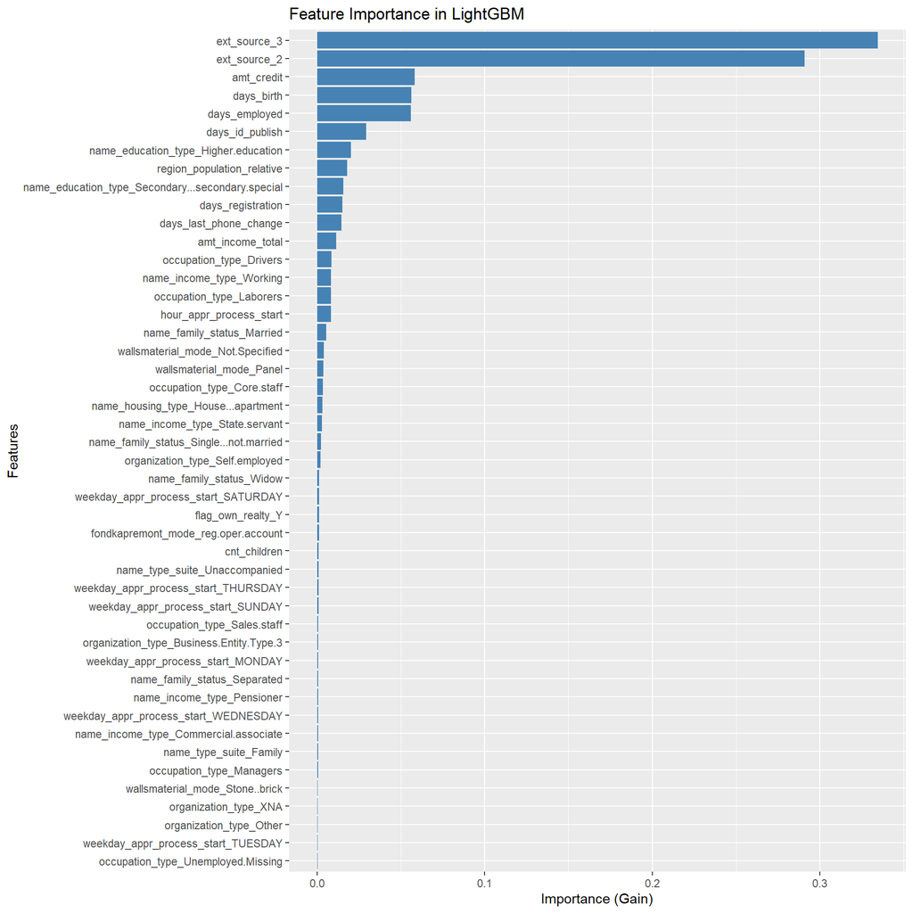

```r
# Plot feature importance
ggplot(importance, aes(x = reorder(Feature, Gain), y = Gain)) +
  geom_bar(stat = "identity", fill = "steelblue") +
  coord_flip() +
  labs(title = "Feature Importance in LightGBM", x = "Features", y = "Importance (Gain)")
```

- **ext_source_3 and ext_source_2:**

These external scores are the most influential predictors. They likely represent external credit ratings or scores, which correlate strongly with the likelihood of default.

- **amt_credit:**

The total credit amount plays a key role, indicating that higher credit amounts may influence the probability of default.

- **days_birth and days_employed:**

These features suggest age and employment tenure. Older borrowers or those with longer employment histories might have lower default risks.

- **name_education_type_Higher.education:**

Education level appears to be predictive, possibly indicating more stable financial behaviors among borrowers with higher education.

- **region_population_relative:**

The population density of a borrower’s location may influence default risk, reflecting economic conditions.

- **days_id_publish and days_registration:**

These features may indicate the stability of a borrower’s identity or account registration, which might be tied to risk.

```r
str(train_x)
```

```
## 'data.frame':    246009 obs. of  46 variables:
##  $ ext_source_2                                     : num  0.622 0.556 0.65 0.323 0.714 ...
##  $ ext_source_3                                     : num  0.535 0.73 0.535 0.535 0.541 ...
##  $ days_birth                                       : num  -16765 -19046 -19005 -19932 -18850 ...
##  $ days_id_publish                                  : num  -291 -2531 -2437 -3458 -2379 ...
##  $ days_registration                                : num  -1186 -4260 -9833 -4311 -4597 ...
##  $ amt_credit                                       : num  1293503 135000 312683 513000 1350000 ...
##  $ days_last_phone_change                           : num  -757 -757 -617 -757 -757 0 -757 -757 -757 -757 ...
##  $ days_employed                                    : num  -1188 -225 -3039 -3038 -449 ...
##  $ amt_income_total                                 : num  12.5 11.1 11.8 11.7 12.7 ...
##  $ region_population_relative                       : num  0.00496 0.01003 0.00802 0.02866 0.00496 ...
##  $ hour_appr_process_start                          : num  11 9 17 11 16 14 8 15 7 10 ...
##  $ cnt_children                                     : num  0 0 0 0 0 0 0 1 0 0 ...
##  $ organization_type_Business.Entity.Type.3         : int  0 0 1 0 0 0 0 0 0 0 ...
##  $ organization_type_Other                          : int  0 0 0 0 1 0 0 0 0 0 ...
```

[output cut: 32 more lines]

```r
str(test_x)
```

```
## 'data.frame':    61502 obs. of  46 variables:
##  $ ext_source_2                                     : num  0.263 0.354 0.724 0.643 0.347 ...
##  $ ext_source_3                                     : num  0.175 0.621 0.492 0.535 0.679 ...
##  $ days_birth                                       : num  -9461 -16941 -13778 -14583 -8728 ...
##  $ days_id_publish                                  : num  -2120 -477 -619 -2056 -1368 ...
##  $ days_registration                                : num  -3648 -4970 -1213 -615 -3494 ...
##  $ amt_credit                                       : num  406598 490496 1350000 773681 299772 ...
##  $ days_last_phone_change                           : num  -757 -757 -757 -188 -757 -239 0 -757 0 -757 ...
##  $ days_employed                                    : num  -637 -1588 -3130 -203 -1157 ...
##  $ amt_income_total                                 : num  12.2 11.5 12 12.1 12 ...
##  $ region_population_relative                       : num  0.0188 0.0358 0.0358 0.01 0.0207 ...
##  $ hour_appr_process_start                          : num  10 16 16 9 7 13 8 11 11 11 ...
##  $ cnt_children                                     : num  0 0 1 0 0 0 0 0 0 0 ...
##  $ organization_type_Business.Entity.Type.3         : int  1 0 1 0 0 0 1 0 0 0 ...
##  $ organization_type_Other                          : int  0 1 0 0 0 0 0 0 0 0 ...
```

[output cut: 32 more lines]

# Step 11: Feature engineering

## Train data

```r
# Apply feature engineering to train_data
# Combine the most important features to capture non-linear relationships.
train_data$ext_source_ratio <- train_data$ext_source_3 / (train_data$ext_source_2 + 1)
train_data$credit_per_income <- train_data$amt_credit / (train_data$amt_income_total + 1)
train_data$age_employment_ratio <- abs(train_data$days_birth) / (abs(train_data$days_employed) + 1)

train_data$amt_credit_bin <- cut(train_data$amt_credit, breaks = c(0, 50000, 100000, 200000, Inf),
                                  labels = c("Low", "Medium", "High", "Very High"))
train_data$age_group <- cut(abs(train_data$days_birth) / 365,
                            breaks = c(0, 25, 35, 50, 65, Inf),
                            labels = c("Young", "Mid-Young", "Mid", "Mid-Old", "Old"))

# For time-based features like days_employed, calculate rolling averages or lagged values.
train_data$rolling_avg_employed <- zoo::rollmean(abs(train_data$days_employed),
                                                 k = 3, fill = NA, align = "right")

# Replace NA values with 0 (or an appropriate value like the column mean or median)
train_data$rolling_avg_employed[is.na(train_data$rolling_avg_employed)] <- 0

train_data[is.na(train_data)] <- 0
```

```r
# After applying feature engineering, split the dataset into predictors (train_x/test_x) and target (train_y/test_y)
train_x <- train_data %>% select(-target)
train_y <- train_data$target
```

## Test data

```r
# Similarly, apply the same feature engineering steps to test_data
test_data$ext_source_ratio <- test_data$ext_source_3 / (test_data$ext_source_2 + 1)
test_data$credit_per_income <- test_data$amt_credit / (test_data$amt_income_total + 1)
test_data$age_employment_ratio <- abs(test_data$days_birth) / (abs(test_data$days_employed) + 1)

test_data$amt_credit_bin <- cut(test_data$amt_credit, breaks = c(0, 50000, 100000, 200000, Inf),
                                labels = c("Low", "Medium", "High", "Very High"))
test_data$age_group <- cut(abs(test_data$days_birth) / 365,
                           breaks = c(0, 25, 35, 50, 65, Inf),
                           labels = c("Young", "Mid-Young", "Mid", "Mid-Old", "Old"))

test_data$rolling_avg_employed <- zoo::rollmean(abs(test_data$days_employed),
                                                k = 3, fill = NA, align = "right")
# Replace NA values with 0 (or an appropriate value like the column mean or median)
test_data$rolling_avg_employed[is.na(test_data$rolling_avg_employed)] <- 0

test_data[is.na(test_data)] <- 0

# Extract predictors and target for the test set
test_x <- test_data %>% select(-target)
test_y <- test_data$target
```

```r
# One-hot encode categorical features in train_x and test_x
dummy_encoder <- dummyVars("~ .", data = train_x)

# Apply encoding to both train_x and test_x
train_x <- predict(dummy_encoder, train_x) %>% as.data.frame()
test_x <- predict(dummy_encoder, test_x) %>% as.data.frame()
# Verify column alignment
identical(colnames(train_x), colnames(test_x))  # Ensure both have the same columns
```

```
## [1] TRUE
```

## Align predictors with application_test_encoded

```r
# Apply feature engineering to application_test_encoded
application_test_encoded$ext_source_ratio <- application_test_encoded$ext_source_3 / (application_test_encoded$ext_source_2 + 1)

application_test_encoded$credit_per_income <- application_test_encoded$amt_credit / (application_test_encoded$amt_income_total + 1)

application_test_encoded$age_employment_ratio <- abs(application_test_encoded$days_birth) / (abs(application_test_encoded$days_employed) + 1)

application_test_encoded$amt_credit_bin <- cut(application_test_encoded$amt_credit,
                                       breaks = c(0, 50000, 100000, 200000, Inf),
                                       labels = c("Low", "Medium", "High", "Very High"))

application_test_encoded$age_group <- cut(abs(application_test_encoded$days_birth) / 365,
                                  breaks = c(0, 25, 35, 50, 65, Inf),
                                  labels = c("Young", "Mid-Young", "Mid", "Mid-Old", "Old"))

application_test_encoded$amt_credit_bin <- factor(application_test_encoded$amt_credit_bin,
                                          levels = c("Low", "Medium", "High", "Very High"))

application_test_encoded$age_group <- factor(application_test_encoded$age_group,
                                     levels = c("Young", "Mid-Young", "Mid", "Mid-Old", "Old"))

# For rolling averages, handle time-based features
application_test_encoded$rolling_avg_employed <- zoo::rollmean(abs(application_test_encoded$days_employed), k = 3, fill = NA, align = "right")

application_test_encoded$rolling_avg_employed[is.na(application_test_encoded$rolling_avg_employed)] <- 0  # Fill NA with 0
```

```r
# One-hot encode categorical features in application_test_encoded

dummy_encoder <- dummyVars("~ .", data = application_test_encoded)

# Apply encoding to both train_x and test_x
application_test_encoded <- predict(dummy_encoder, application_test_encoded) %>% as.data.frame()

# Verify column alignment
identical(colnames(train_x), colnames(application_test_encoded))  # Ensure both have the same columns
```

```
## [1] TRUE
```

```r
# Updated Model Training with Feature Engineering

lgb_train_2 <- lgb.Dataset(data = as.matrix(train_x), label = as.numeric(train_y) - 1)
lgb_test_2 <- lgb.Dataset(data = as.matrix(test_x), label = as.numeric(test_y) - 1)

# Train LightGBM with the same parameters
lgb_model_2 <- lgb.train(
  params = lgb_params,
  data = lgb_train_2,
  nrounds = 100,
  valids = list(test = lgb_test_2),
  early_stopping_rounds = 10
)
```

```
## [LightGBM] [Warning] Found whitespace in feature_names, replace with underlines
## [LightGBM] [Info] Number of positive: 19860, number of negative: 226149
## [LightGBM] [Info] Auto-choosing row-wise multi-threading, the overhead of testing was 0.016649 seconds.
## You can set `force_row_wise=true` to remove the overhead.
## And if memory is not enough, you can set `force_col_wise=true`.
## [LightGBM] [Info] Total Bins 3354
## [LightGBM] [Info] Number of data points in the train set: 246009, number of used features: 57
## [LightGBM] [Info] [binary:BoostFromScore]: pavg=0.080729 -> initscore=-2.432486
## [LightGBM] [Info] Start training from score -2.432486
## [1]:  test's auc:0.704319
## Will train until there is no improvement in 10 rounds.
## [2]:  test's auc:0.712637
## [3]:  test's auc:0.718131
## [4]:  test's auc:0.719742
## [5]:  test's auc:0.720854
## [6]:  test's auc:0.721755
## [7]:  test's auc:0.722721
## [8]:  test's auc:0.723364
## [9]:  test's auc:0.723621
## [10]:  test's auc:0.724189
## [11]:  test's auc:0.724389
## [12]:  test's auc:0.724876
## [13]:  test's auc:0.725212
## [14]:  test's auc:0.725739
## [15]:  test's auc:0.726259
## [16]:  test's auc:0.726659
## [17]:  test's auc:0.727123
## [18]:  test's auc:0.727206
## [19]:  test's auc:0.727541
## [20]:  test's auc:0.727846
## [21]:  test's auc:0.728053
## [22]:  test's auc:0.728292
## [23]:  test's auc:0.728587
## [24]:  test's auc:0.728663
## [25]:  test's auc:0.728815
## [26]:  test's auc:0.72919
## [27]:  test's auc:0.729354
## [28]:  test's auc:0.729597
## [29]:  test's auc:0.729873
## [30]:  test's auc:0.729805
```

[output cut: 55 more lines]

```
## [86]:  test's auc:0.734487
## [87]:  test's auc:0.734473
## [88]:  test's auc:0.734533
## [89]:  test's auc:0.73465
## [90]:  test's auc:0.734564
## [91]:  test's auc:0.734525
## [92]:  test's auc:0.734446
## [93]:  test's auc:0.734443
## [94]:  test's auc:0.734437
## [95]:  test's auc:0.734452
## [96]:  test's auc:0.734393
## [97]:  test's auc:0.734366
## [98]:  test's auc:0.734389
## [99]:  test's auc:0.73435
## Early stopping, best iteration is: [89]:  test's auc:0.73465
```

```r
# Predictions and evaluation
lgb_predictions_2 <- predict(lgb_model_2, as.matrix(test_x))
lgb_class_2 <- ifelse(lgb_predictions_2 > 0.5, 1, 0)
lgb_confusion_2 <- confusionMatrix(factor(lgb_class_2), test_y, positive = "1")
print(lgb_confusion_2)
```

```
## Confusion Matrix and Statistics
##
##           Reference
## Prediction     0     1
##          0 38644  1691
##          1 17893  3274
##
##                Accuracy : 0.6816
##                  95% CI : (0.6779, 0.6853)
##     No Information Rate : 0.9193
##     P-Value [Acc > NIR] : 1
##
##                   Kappa : 0.1378
##
##  Mcnemar's Test P-Value : <2e-16
##
##             Sensitivity : 0.65942
##             Specificity : 0.68352
##          Pos Pred Value : 0.15467
##          Neg Pred Value : 0.95808
##              Prevalence : 0.08073
##          Detection Rate : 0.05323
##    Detection Prevalence : 0.34417
##       Balanced Accuracy : 0.67147
##
##        'Positive' Class : 1
##
```

```r
# Calculate F1 Score
f1_score_lgb <- F1_Score(y_pred = factor(lgb_class_2, levels = c(0, 1)),
                     y_true = factor(test_y, levels = c(0, 1)),
                     positive = "1")
print(paste("F1 Score:", f1_score_lgb))
```

```
## [1] "F1 Score: 0.250574008878004"
```

```r
# Calculate AUC
roc_curve <- roc(test_y, lgb_predictions_2)
auc_value <- auc(roc_curve)
print(paste("AUC:", auc_value))
```

```
## [1] "AUC: 0.734650236890916"
```

# Step 12: Adjusting threshold for internal exploration (not for Kaggle)

```r
# Adjust threshold for prediction
threshold <- 0.5037  # Adjust based on your evaluation
lgb_class_adjusted <- ifelse(lgb_predictions_2 > threshold, 1, 0)

# Recalculate confusion matrix
adjusted_confusion <- confusionMatrix(factor(lgb_class_adjusted), test_y, positive = "1")
print(adjusted_confusion)
```

```
## Confusion Matrix and Statistics
##
##           Reference
## Prediction     0     1
##          0 38944  1712
##          1 17593  3253
##
##                Accuracy : 0.6861
##                  95% CI : (0.6824, 0.6898)
##     No Information Rate : 0.9193
##     P-Value [Acc > NIR] : 1
##
##                   Kappa : 0.1399
##
##  Mcnemar's Test P-Value : <2e-16
##
##             Sensitivity : 0.65519
##             Specificity : 0.68882
##          Pos Pred Value : 0.15605
##          Neg Pred Value : 0.95789
##              Prevalence : 0.08073
##          Detection Rate : 0.05289
##    Detection Prevalence : 0.33895
##       Balanced Accuracy : 0.67200
##
##        'Positive' Class : 1
##
```

```r
f1_score_adjusted <- F1_Score(y_pred = factor(lgb_class_adjusted, levels = c(0, 1)),
                              y_true = factor(test_y, levels = c(0, 1)),
                              positive = "1")
print(paste("F1 Score (Adjusted Threshold):", round(f1_score_adjusted, 4)))
```

```
## [1] "F1 Score (Adjusted Threshold): 0.2521"
```

```r
# Calculate AUC
roc_curve_adjusted <- roc(test_y, lgb_predictions_2)
auc_value_adjusted <- auc(roc_curve_adjusted)
print(paste("AUC (Adjusted Threshold):", round(auc_value_adjusted, 4)))
```

```
## [1] "AUC (Adjusted Threshold): 0.7347"
```

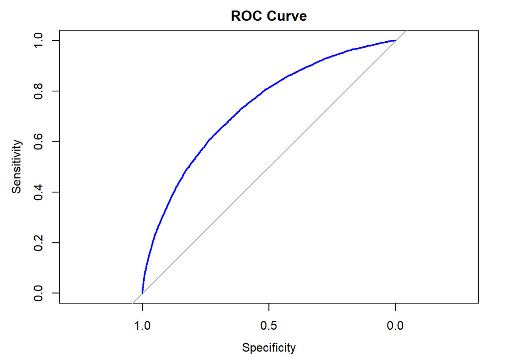

```r
# Optional: Plot ROC Curve
plot(roc_curve_adjusted, main = "ROC Curve", col = "blue", lwd = 2)
```

```r
# Find optimal threshold based on Youden's J statistic
optimal_coords <- coords(roc_curve_adjusted, "best", ret = "threshold", best.method = "youden")
print(paste("Optimal Threshold (Youden):", optimal_coords))
```

```
## [1] "Optimal Threshold (Youden): 0.503738956146021"
```

This provides a balance between precision (avoiding false positives) and recall (minimizing false negatives).

## Comparison table

```r
# Create a data frame to store and compare metrics
comparison_table_5 <- data.frame(
  Model = c("LightGBM (Initial)",
            "LightGBM (After Feature Engineering (FE))",
            "LightGBM (FE + Threshold Adjusted)"),

  Accuracy = c(lgb_confusion$overall["Accuracy"],
               lgb_confusion_2$overall["Accuracy"],
               adjusted_confusion$overall["Accuracy"]),

  Sensitivity = c(lgb_confusion$byClass["Sensitivity"],
                  lgb_confusion_2$byClass["Sensitivity"],
                  adjusted_confusion$byClass["Sensitivity"]),

  Specificity = c(lgb_confusion$byClass["Specificity"],
                  lgb_confusion_2$byClass["Specificity"],
                  adjusted_confusion$byClass["Specificity"]),

  Precision = c(lgb_confusion$byClass["Pos Pred Value"],
                lgb_confusion_2$byClass["Pos Pred Value"],
                adjusted_confusion$byClass["Pos Pred Value"]),

  F1_Score = c(f1_score,
               f1_score_lgb,
               f1_score_adjusted),

  AUC = c(lgb_auc,
          auc_value,
          auc_value_adjusted),

  Optimal_Threshold =  c(NA, NA, 0.5037)  # Optimal threshold for adjusted
)


# Display the comparison table using kable
kable(comparison_table_5, caption = "Comparison of LightGBM Models with Metrics")
```

Comparison of LightGBM Models with Metrics

| Model | Accuracy | Sensitivity | Specificity | Precision | F1_Score | AUC | Optimal_Threshold |
| --- | --- | --- | --- | --- | --- | --- | --- |
| LightGBM (Initial) | 0.6801242 | 0.6670695 | 0.6812707 | 0.1552597 | 0.2518919 | 0.7339675 | NA |
| LightGBM (After Feature Engineering (FE)) | 0.6815713 | 0.6594159 | 0.6835170 | 0.1546747 | 0.2505740 | 0.7346502 | NA |
| LightGBM (FE + Threshold Adjusted) | 0.6861078 | 0.6551863 | 0.6888232 | 0.1560491 | 0.2520631 | 0.7346502 | 0.5037 |

The LightGBM model with feature engineering and a threshold of 0.5037 offers a better “fit”, offering an AUC of 0.7347, F1-Score of 0.2521, accuracy of 68.61%, sensitivity of 65.52%, and specificity of 68.88%. It balances predictive power and fairness by combining a balance in precision and recall.

# Step 13: Preparing the application_test for Prediction

## Verifying Feature Alignment

```r
# Ensure SK_ID_CURR is included and of the correct type
application_test_encoded$sk_id_curr <- application_test$sk_id_curr
application_test_encoded$sk_id_curr <- as.integer(application_test_encoded$sk_id_curr)
```

```r
# Get the feature names for both datasets and compare
train_x_features <- colnames(train_x)
test_encoded_features <- colnames(application_test_encoded)

# Identify missing or extra features
# Find features present in train_x but not in application_test_encoded
missing_in_test <- setdiff(train_x_features, test_encoded_features)
# Find features present in application_test_encoded but not in train_x
extra_in_test <- setdiff(test_encoded_features, train_x_features)

# Print the results
if (length(missing_in_test) == 0 && length(extra_in_test) == 0) {
  cat("The features in train_x and application_test_encoded are identical.\n")
} else {
  cat("Features missing in application_test_encoded:\n", missing_in_test, "\n")
  cat("Extra features in application_test_encoded:\n", extra_in_test, "\n")
}
```

```
## Features missing in application_test_encoded:
##
## Extra features in application_test_encoded:
##  sk_id_curr
```

## Generating Predictions and Creating Submission File

```r
# Ensure SK_ID_CURR is not used in prediction
app_test_x <- application_test_encoded %>% select(-sk_id_curr)

# Predict probabilities using the trained model
final_predictions <- predict(lgb_model_2, newdata = as.matrix(app_test_x))

# Create the submission file
submission <- data.frame(
  SK_ID_CURR = application_test_encoded$sk_id_curr,
  TARGET = final_predictions
)

# Save submission to CSV
write.csv(submission, "submission_1.csv", row.names = FALSE)
```

## Submission Results Visualization (Kaggle Score 1)

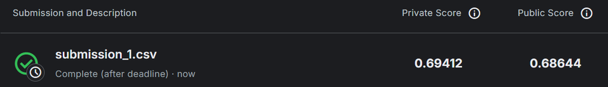

# Step 14: Parameter Tuning

To find the optimal parameters, I ran a grid search using the following configuration:

```r
# Set a parameter grid
param_grid <- expand.grid(
  num_leaves = c(15, 31, 63),
  max_depth = c(5, 8, 10),
  learning_rate = c(0.01, 0.05, 0.1),
  feature_fraction = c(0.6, 0.8, 1.0),
  bagging_fraction = c(0.7, 0.8, 0.9)
)

# Loop through the grid and evaluate each combination
results <- data.frame()
for (i in 1:nrow(param_grid)) {
  params <- param_grid[i, ]
  model <- lgb.train(
    params = list(
      objective = "binary",
      metric = "auc",
      num_leaves = params$num_leaves,
      max_depth = params$max_depth,
      learning_rate = params$learning_rate,
      feature_fraction = params$feature_fraction,
      bagging_fraction = params$bagging_fraction,
      bagging_freq = 5
    ),
    data = lgb_train_2,
    nrounds = 500,
    valids = list(test = lgb_test_2),
    early_stopping_rounds = 20
  )
  auc <- model$best_score
  results <- rbind(results, cbind(params, auc))
}
# Print the best combination
best_params <- results[which.max(results$auc), ]
print(best_params)
```

- `num_leaves`: 15, 31, 63
- `max_depth`: 5, 8, 10
- `learning_rate`: 0.01, 0.05, 0.1
- `feature_fraction`: 0.6, 0.8, 1.0
- `bagging_fraction`: 0.7, 0.8, 0.9

## Best Parameters Summary

This grid search took approximately **1 hour** to complete, and the best parameter combination was:

[output not shown]

# Step 15: Final Model Training with Tuned Parameters

```r
lgb_params_2 <- list(
  objective = "binary",
  metric = "auc",
  scale_pos_weight = sum(train_y == 0) / sum(train_y == 1),  # Class weights
  learning_rate = 0.01,  # Lower learning rate
  num_leaves = 172,  # Keep it moderately high
  max_depth = 5,  # Limit tree depth
  feature_fraction = 0.6,
  bagging_fraction = 0.9,
  bagging_freq = 5,  # Retain same bagging frequency
  lambda_l1 = 0.1,  # Add L1 regularization
  lambda_l2 = 0.1   # Add L2 regularization
)

# Train LightGBM with tuned parameters
lgb_model_3 <- lgb.train(
  params = lgb_params_2,
  data = lgb_train_2,
  nrounds = 500,  # Increase the number of rounds
  valids = list(test = lgb_test_2),
  early_stopping_rounds = 20,  # Use higher patience
  verbose = -1
)
```

## Generating Predictions and Creating Submission File

```r
# Predict probabilities using the trained model
final_predictions_2 <- predict(lgb_model_3, newdata = as.matrix(app_test_x))

# Create the submission file
submission_2 <- data.frame(
  SK_ID_CURR = application_test_encoded$sk_id_curr,
  TARGET = final_predictions_2
)

# Save submission to CSV
write.csv(submission_2, "submission_2.csv", row.names = FALSE)
```

## Submission Results Visualization (Kaggle score 2)

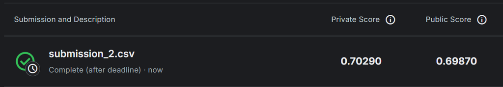

# Step 16: Cross-Validation Results

```r
# Create 5 stratified folds
folds <- createFolds(train_y, k = 5, list = TRUE, returnTrain = TRUE)

cv_results <- data.frame()  # To store AUC for each fold

for (i in seq_along(folds)) {
  # Get train/test split
  train_indices <- folds[[i]]
  test_indices <- setdiff(seq_len(nrow(train_x)), train_indices)

  train_x_fold <- train_x[train_indices, ]
  train_y_fold <- train_y[train_indices]

  test_x_fold <- train_x[test_indices, ]
  test_y_fold <- train_y[test_indices]

  # Prepare LightGBM datasets
  lgb_train_fold <- lgb.Dataset(data = as.matrix(train_x_fold), label = as.numeric(train_y_fold) - 1)
  lgb_test_fold <- lgb.Dataset(data = as.matrix(test_x_fold), label = as.numeric(test_y_fold) - 1)

  # Train model on this fold
  lgb_model_cv <- lgb.train(
    params = lgb_params_2,
    data = lgb_train_fold,
    nrounds = 500,
    valids = list(test = lgb_test_fold),
    early_stopping_rounds = 20,
    verbose = -1
  )

  # Evaluate performance
  fold_auc <- lgb_model_cv$best_score
  cv_results <- rbind(cv_results, data.frame(Fold = i, AUC = fold_auc))
}

# Print cross-validation results
print(cv_results)
```

```
##   Fold       AUC
## 1    1 0.7399256
## 2    2 0.7394077
## 3    3 0.7275697
## 4    4 0.7277556
## 5    5 0.7328640
```

```r
avg_auc <- mean(cv_results$AUC)
cat("Average AUC across folds:", avg_auc, "\n")
```

```
## Average AUC across folds: 0.7335045
```

# Business Analysis based on the predictions

## Add Predictions and Expected Risk

```r
# Add predicted probabilities to the dataset
application_test_encoded$predicted_default_probability <- final_predictions_2

# Calculate expected financial risk
application_test_encoded$expected_risk <- application_test_encoded$amt_credit * application_test_encoded$predicted_default_probability
```

## Classify Clients by Risk

```r
# Define risk categories
application_test_encoded$risk_category <- cut(
  application_test_encoded$predicted_default_probability,
  breaks = c(0, 0.3, 0.6, 1),
  labels = c("Low Risk", "Medium Risk", "High Risk"),
  right = FALSE
)
```

## Summarize Insights for Each Risk Category

```r
# Summarize total loans, average loans, and default probability by risk category
risk_summary <- application_test_encoded %>%
  group_by(risk_category) %>%
  summarise(
    total_loans = sum(amt_credit, na.rm = TRUE),
    avg_loan = mean(amt_credit, na.rm = TRUE),
    avg_default_probability = mean(predicted_default_probability, na.rm = TRUE),
    avg_income = mean(amt_income_total, na.rm = TRUE),
    avg_days_employed = mean(days_employed, na.rm = TRUE)
  )


# Display the summarized table using kable
kable(risk_summary, caption = "Summary of Loans and Default Probabilities by Risk Category")
```

Summary of Loans and Default Probabilities by Risk Category

| risk_category | total_loans | avg_loan | avg_default_probability | avg_income | avg_days_employed |
| --- | --- | --- | --- | --- | --- |
| Low Risk | 8993041583 | 578963.6 | 0.2129953 | 190187.2 | 92783.00 |
| Medium Risk | 11664000549 | 507660.2 | 0.4401427 | 178542.8 | 68056.31 |
| High Risk | 4530953660 | 442692.1 | 0.6909359 | 160342.2 | 27811.10 |

## Define Personas

```r
# Extract and display the 20 best predictors based on importance
importance_predictors <- lgb.importance(lgb_model_3, percentage = TRUE)
top_20_predictors <- importance_predictors[1:20, ]  # Select top 20 predictors

# Display the top 20 predictors using kable
kable(top_20_predictors, caption = "Top 20 Predictors Based on Importance")
```

Top 20 Predictors Based on Importance

| Feature | Gain | Cover | Frequency |
| --- | --- | --- | --- |
| ext_source_2 | 0.2952963 | 0.1848904 | 0.1100672 |
| ext_source_3 | 0.2482804 | 0.1530346 | 0.0839042 |
| ext_source_ratio | 0.1092001 | 0.0492162 | 0.0535004 |
| days_employed | 0.0497267 | 0.0508197 | 0.0509558 |
| days_birth | 0.0393871 | 0.0574218 | 0.0805768 |
| amt_credit | 0.0331862 | 0.0658540 | 0.0824688 |
| name_education_type_Higher.education | 0.0308914 | 0.0296084 | 0.0227050 |
| credit_per_income | 0.0228845 | 0.0397252 | 0.0660273 |
| days_id_publish | 0.0211442 | 0.0448668 | 0.0525217 |
| age_employment_ratio | 0.0144769 | 0.0189126 | 0.0400600 |
| name_education_type_Secondary…secondary.special | 0.0125268 | 0.0148918 | 0.0129836 |
| name_income_type_Working | 0.0111479 | 0.0174973 | 0.0133751 |
| days_last_phone_change | 0.0110462 | 0.0243934 | 0.0287075 |
| region_population_relative | 0.0098264 | 0.0151381 | 0.0351015 |
| occupation_type_Drivers | 0.0094215 | 0.0309754 | 0.0163111 |
| days_registration | 0.0089953 | 0.0137007 | 0.0370588 |
| occupation_type_Laborers | 0.0083545 | 0.0305666 | 0.0133098 |
| amt_income_total | 0.0066805 | 0.0096308 | 0.0272721 |
| rolling_avg_employed | 0.0066383 | 0.0080158 | 0.0314478 |
| name_family_status_Married | 0.0057777 | 0.0246285 | 0.0137666 |

### Combine age_group Columns

```r
# Recreate age_group column from one-hot encoding
application_test_encoded <- application_test_encoded %>%
  mutate(
    age_group = case_when(
      `age_group.Young` == 1 ~ "Young",
      `age_group.Mid-Young` == 1 ~ "Mid-Young",
      `age_group.Mid` == 1 ~ "Mid",
      `age_group.Mid-Old` == 1 ~ "Mid-Old",
      `age_group.Old` == 1 ~ "Old",
      TRUE ~ "Unknown"
    )
  )
```

### Combine amt_credit_bin Columns

```r
# Recreate amt_credit_bin column from one-hot encoding
application_test_encoded <- application_test_encoded %>%
  mutate(
    amt_credit_bin = case_when(
      `amt_credit_bin.Low` == 1 ~ "Low",
      `amt_credit_bin.Medium` == 1 ~ "Medium",
      `amt_credit_bin.High` == 1 ~ "High",
      `amt_credit_bin.Very High` == 1 ~ "Very High",
      TRUE ~ "Unknown"
    )
  )
```

## Summarize top features for each risk category

```r
# Summarize top features for each risk category
persona_features <- application_test_encoded %>%
  group_by(risk_category) %>%
  summarise(
    avg_ext_source_ratio = mean(ext_source_ratio, na.rm = TRUE),
    common_age_group = names(sort(table(age_group), decreasing = TRUE))[1],  # Most common age group
    avg_days_employed = mean(days_employed, na.rm = TRUE),
    avg_loan = mean(amt_credit, na.rm = TRUE),
    avg_income = mean(amt_income_total, na.rm = TRUE),
    avg_amt_credit = mean(amt_credit, na.rm = TRUE),
    avg_credit_per_income = mean(credit_per_income, na.rm = TRUE),
    avg_days_id_publish = mean(days_id_publish, na.rm = TRUE),
    avg_age_employment_ratio = mean(age_employment_ratio, na.rm = TRUE),
    pct_higher_education = mean(name_education_type_Higher.education, na.rm = TRUE)
  )
```

## Visualize Personas

```r
personas_table <- persona_features %>%
  mutate(
    key_characteristics = case_when(
      risk_category == "Low Risk" ~ "Stable employment, high external scores, low credit-to-income ratio",
      risk_category == "Medium Risk" ~ "Moderate external scores, medium loan amounts, some employment gaps",
      risk_category == "High Risk" ~ "Low external scores, high credit-to-income ratio, less stable employment"
    )
  )
```

```r
# Display personas_table using kable with corrected column names
kable(personas_table, caption = "Personas Table with Key Characteristics")
```

Personas Table with Key Characteristics

| risk_category | avg_ext_source_ratio | common_age_group | avg_days_employed | avg_loan | avg_income | avg_amt_credit | avg_credit_per_income | avg_days_id_publish | avg_age_employment_ratio | pct_higher_education | key_characteristics |
| --- | --- | --- | --- | --- | --- | --- | --- | --- | --- | --- | --- |
| Low Risk | 0.3948238 | Mid-Old | 92783.00 | 578963.6 | 190187.2 | 578963.6 | 3.310384 | -3447.697 | 8.524817 | 0.3961244 | Stable employment, high external scores, low credit-to-income ratio |
| Medium Risk | 0.3136906 | Mid | 68056.31 | 507660.2 | 178542.8 | 507660.2 | 3.127109 | -3023.060 | 13.525044 | 0.2294133 | Moderate external scores, medium loan amounts, some employment gaps |
| High Risk | 0.2122660 | Mid | 27811.10 | 442692.1 | 160342.2 | 442692.1 | 3.041421 | -2515.075 | 18.042163 | 0.1066927 | Low external scores, high credit-to-income ratio, less stable employment |

This analysis highlights clear differences between risk categories based on external source ratios, employment stability, education levels, and loan behavior. These insights can guide product design, marketing strategies, and risk mitigation measures to improve portfolio quality and business profitability.

NOTE: Employment stability values (e.g, 92,783 days) suggest possible outliers. I didnt address this because it was the test data, so it is important to leave it like it is.

## Enhanced Personas (with simulations)

```r
# Step 1: Simulate repayment_delay_days based on risk_category
set.seed(42)
application_test_encoded <- application_test_encoded %>%
  mutate(
    repayment_delay_days = case_when(
      risk_category == "Low Risk" ~ rnorm(n(), mean = 2, sd = 1),
      risk_category == "Medium Risk" ~ rnorm(n(), mean = 10, sd = 5),
      risk_category == "High Risk" ~ rnorm(n(), mean = 30, sd = 15)
    ),
    repayment_delay_days = pmax(0, repayment_delay_days)  # Ensure non-negative values
  )

# Step 2: Summarize enriched personas with profitability and repayment metrics
profitability_personas <- application_test_encoded %>%
  group_by(risk_category) %>%
  summarise(
    avg_loan = mean(amt_credit, na.rm = TRUE),
    avg_income = mean(amt_income_total, na.rm = TRUE),
    avg_credit_to_income = mean(credit_per_income, na.rm = TRUE),
    avg_days_employed = mean(days_employed, na.rm = TRUE),
    avg_repayment_delay = mean(repayment_delay_days, na.rm = TRUE),
    common_age_group = names(sort(table(age_group), decreasing = TRUE))[1]
  ) %>%
  mutate(
    # Loan profitability metrics
    interest_rate = 0.08,  # Annual interest rate
    default_probability = case_when(
      risk_category == "Low Risk" ~ 0.01,
      risk_category == "Medium Risk" ~ 0.05,
      risk_category == "High Risk" ~ 0.20
    ),
    expected_interest_revenue = avg_loan * interest_rate,
    expected_loss = avg_loan * default_probability,
    net_profit = expected_interest_revenue - expected_loss,
    risk_adjusted_roi = net_profit / avg_loan * 100
  )


# Step 3: Display the combined results
kable(profitability_personas, caption = "Combined Results of Profitability Personas")
```

Combined Results of Profitability Personas

| risk_category | avg_loan | avg_income | avg_credit_to_income | avg_days_employed | avg_repayment_delay | common_age_group | interest_rate | default_probability | expected_interest_revenue | expected_loss | net_profit | risk_adjusted_roi |
| --- | --- | --- | --- | --- | --- | --- | --- | --- | --- | --- | --- | --- |
| Low Risk | 578963.6 | 190187.2 | 3.310384 | 92783.00 | 2.004843 | Mid-Old | 0.08 | 0.01 | 46317.09 | 5789.636 | 40527.45 | 7 |
| Medium Risk | 507660.2 | 178542.8 | 3.127109 | 68056.31 | 10.012654 | Mid | 0.08 | 0.05 | 40612.82 | 25383.010 | 15229.81 | 3 |
| High Risk | 442692.1 | 160342.2 | 3.041421 | 27811.10 | 30.357741 | Mid | 0.08 | 0.20 | 35415.37 | 88538.420 | -53123.05 | -12 |

# Client Profiles and Business Recommendations

**Low Risk Clients:**

- **Profile**
- Age Group: Mid-Old (51–65).
- Loan Size: $578,964 | Income: $190,187 | External Score: 0.3948.
- Employment: Very stable (92,783 days).
- Education: 39.6% with higher education.
- Repayment Behavior: Minimal repayment delay (2 days on average).
  - **Profitability Metrics:** (Simulations)
- Expected Interest Revenue: $46,317.
- Expected Loss: $5,790.
- Net Profit: $40,527.
- Risk-Adjusted ROI: 7%.
  - **Business Insight:**
- Offer premium loans with low rates and flexible terms.
- Target high-income, educated clients for investment products.

**Medium Risk Clients:**

- **Profile**
- Age Group: Mid (36–50).
- Loan Size: $507,660 | Income: $178,543 | External Score: 0.3137.
- Employment: Stable (68,056 days).
- Education: 22.9% with higher education.
- Repayment Behavior: Moderate repayment delay (10 days on average).
  - **Profitability Metrics:** (Simulations)
- Expected Interest Revenue: $40,613.
- Expected Loss: $25,383.
- Net Profit: $15,230.
- Risk-Adjusted ROI: 3%.
  - **Business Insight:**
- Provide standard loans with moderate rates.
- Introduce flexible repayment plans and credit counseling.

**High Risk Clients**

- **Profile:**
- Age Group: Mid (36–50).
- Loan Size: $442,692 | Income: $160,342 | External Score: 0.2123.
- Employment: Unstable (27,811 days).
- Education: 10.7% with higher education.
- Repayment Behavior: Significant repayment delay (30 days on average).
  - **Profitability Metrics:** (Simulations)
- Expected Interest Revenue: $35,415.
- Expected Loss: $88,538.
- Net Profit: -$53,123 (negative).
- Risk-Adjusted ROI: -12% (loss-making).
  - **Business Insight:**
- Limit loans to collateral-based products.
- Focus on short-term plans and require stricter credit checks.
- Introduce financial literacy programs to improve repayment behavior.

## Key Metrics to Focus On

1. Education: Higher education correlates with lower risk: Low Risk: 39.6% | Medium Risk: 22.9% | High Risk: 10.7%.
2. External Score: Threshold of 0.3 is ideal for safer loans.
3. Employment Stability: Key for risk assessment: Low Risk: 92,783 days | Medium Risk: 68,056 days | High Risk: 27,811 days.
4. Credit-to-Income Ratio: Low Risk: 3.31 | Medium Risk: 3.13 | High Risk: 3.04.

**SIMULATIONS**

5. Profitability Varies with Risk: Low-risk clients yield the highest net profit and ROI, making them ideal for long-term loan products.
6. Repayment Behavior as a Key Indicator: Average repayment delay increases significantly with risk.

## Action Plan

**1. Low Risk:** Expand premium loan offerings and target high earners with targeted marketing campaing.

**2. Medium Risk:** Offer standard loans with education on financial literacy.

**3. High Risk:** Focus on collateral-based lending and short-term plans.